# Introduction to Python

# Scikit-Learn: Representation Learning

Different names for the same idea:

- Representation learning
- Learning embeddings
- Manifold learning
- Dimensionality reduction

There are two main goals:

- Reduce dimensionality to save memory/CPU in later supervised/unsupervised tasks, or for visualisation
- Achieve a "better" representation for data which allows downstream algorithms to succeed.

It can be linear:

- Principal components analysis (PCA)
- Random projection

It can be non-linear:

- $t$-SNE
- Multi-dimensional scaling
- Locally linear embedding

In this notebook, we'll see some examples of representation learning. We'll also see how the Scikit-Learn API makes it easy to try out multiple techniques at once.

The usual imports for plotting.

```python
import matplotlib.pyplot as plt
import seaborn as sns
%matplotlib inline
```

We'll import a few representation learning models, some for the exercises.

```python
from sklearn.manifold import MDS, TSNE, LocallyLinearEmbedding
from sklearn.decomposition import PCA
```

We're going to work with a small dataset of hand-written digits. (Not MNIST.)

```python
from sklearn.datasets import load_digits
digits = load_digits()
digits.images.shape
```

```
(1797, 8, 8)
```

Here is a nice function (from PDSH) for plotting some of the images with labels.

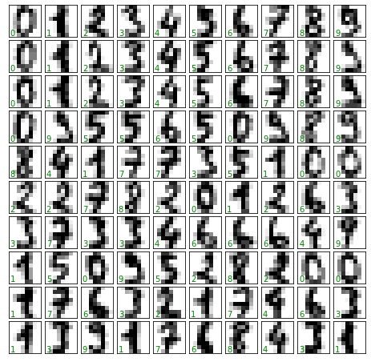

```python
# from PDSH -- for illustration only - you don't need to understand details
fig, axes = plt.subplots(10, 10, figsize=(8, 8),
                         subplot_kw={'xticks':[], 'yticks':[]},
                         gridspec_kw=dict(hspace=0.1, wspace=0.1))

for i, ax in enumerate(axes.flat):
    ax.imshow(digits.images[i], cmap='binary', interpolation='nearest')
    ax.text(0.05, 0.05, str(digits.target[i]),
            transform=ax.transAxes, color='green')
```

Scikit-Learn expects each $X$ as a flat vector.

```python
X = digits.images.reshape(1797, 64)
```

And here is a function to plot the embedding.

```python
def plot_embed(X):
    sns.scatterplot(X[:, 0], X[:, 1],
                    hue=digits.target,
                    legend="full",
                    palette="Paired")
    plt.gcf().set_size_inches(4, 4)
    plt.show(); plt.close()
```

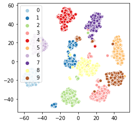

```python
models = [TSNE(n_components=2)]
for model in models:
    model.fit(X)
    emb = model.embedding_
    plot_embed(emb)
```

Observe the range of $x$ and $y$ values. We don't try to interpret these axes. In fact, one could rotate the whole thing by 90 degrees, or any other amount, and it would be the "same" result -- for visualisation, or for downstream algorithms.

### PCA

`sklearn.decomposition.PCA` is the class to use for Principal Components Analysis. In principle it should have an API similar to $t$-SNE. But there are a couple of differences:

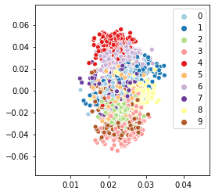

```python
models = [PCA(n_components=2)]

for model in models:
    model.fit(X.T) # transpose here and below
    emb = model.components_.T # not .embedding_
    plot_embed(emb)
```

PCA seems not to produce a nice separated embedding, like $t$-SNE. But it has the important advantage that after fitting on `X`, we can later map new data into the embedding space. In Scikit-Learn's terms, `PCA` is *inductive* because it has a `transform` method. `TSNE` is *transductive* because it doesn't. As a result, `PCA` can be used to transform data for downstream supervised learning tasks but `TSNE` can't.

**Exercise**:

1. More than any other ML technique, it's essential to look at the result of representation learning, and judge it subjectively. Look at the embedding produced by $t$-SNE. Are digits in "good" places?
2. Add some other models so that they run in our loop. Consider `MDS`, `LocallyLinearEmbedding`, or whatever you like from the same module. Use a 2D embedding in each case. Do they need different hyperparameters? Note: `MDS.fit()` takes ~60s on a 5-year-old Thinkpad.

**Exercise**:

1. Each model has a different definition for `score()`, so it is not useful to compare across models. But it is interesting to compare performance for different dimensions. Make a table showing the score for each model, and for several different dimensionalities (e.g. $n=2, 4, 8, 16$, bearing in mind the digits themselves are 64D) and bearing in mind that we can only visualise 2D.

**Solution 1**:

I would remark e.g. that digits 3 and 9 are close by each other, and so are 4 and 7. These reflect similarities in digit shape.

**Solution 2**:

```
models = [TSNE(n_components=2), LocallyLinearEmbedding(n_components=2), MDS(n_components=2)]
```

should do the trick. In my run, `LocallyLinearEmbedding` does not do well, but it can be useful for some datasets.

**Solution 3**:

Just use eg `n_componentss = [2, 4, 8, 16]` and iterate `for n_components in n_componentss:`.

[figure not shown]

# Scikit-Learn: Summary

We have now seen supervised, unsupervised, and representation learning. All use the Scikit-Learn *Estimator* API. In this notebook, we'll look at a few more details of that API, and then briefly summarise what is in Scikit-Learn.

### The Estimator API

"the main API implemented by scikit-learn is that of the estimator. An estimator is any object that learns from data; it may be a classification, regression or clustering algorithm or a transformer that extracts/filters useful features from raw data."

An estimator object has a `fit` method which may accept `X` or `X` and `y`:

```
estimator.fit(X)
# OR...
estimator.fit(X, y)
```

A predictor object is an estimator which also has a `predict` method:

```
estimator.predict(X)
```

Some predictors whose `predict` output is discrete (e.g. clustering or classification) will implement either `predict_proba` or `decision_function`, which return real values:

```
estimator.predict_proba(X)
```

The `predict` method is then usually implemented as a threshold over the result, e.g.:

```
def predict(self, X):
        return self.predict_proba(X) > self.threshold
```

A *transformer* is an estimator with either `transform` or `fit_transform`. Often transformers are representation learning approaches. `fit_transform` is just a shortcut to calling `fit` and then `transform` on the same data.

A *model* is an object with a `score` method which evaluates how good it is, e.g. $R^2$ or classification accuracy. Higher is always better.

```
score(X)
```

or

```
score(X, y)
```

For a little more detail on this, see https://scikit-learn.org/stable/tutorial/statistical_inference/settings.html#estimators-objects

A typical example is `LogisticRegression`:

```
lr = LogisticRegression()
lr.fit(X, y)
lr.score(X_test, y_test)
lr.predict_proba(X_query)
lr.predict(X_query)
```

### Semantics

Calling `predict` **before** `fit` is disallowed.

After fitting, the estimator object will usually have some new attributes named with a trailing underscore, e.g. `lr.coef_` and `lr.intercept_` for linear regression, or `support_vectors_` and some others for an SVM.

Also, a call to `fit` over-writes the result of any previous call.

```
lr.fit(X1, y1)
lr.fit(X2, y2)
```

has the same effect as just: `lr.fit(X2, y2)`.

(A few estimators allow `warm_start=True` in the constructor, or `partial_fit(X, y)`, so that we can pick up training where we left off. But we won't cover these.)

### Scikit-Learn Summary Table

| Problem | Example | Technique | Create | Fit | Evaluate | Use |
| --- | --- | --- | --- | --- | --- | --- |
| **Unsupervised** |  |  |  |  |  |  |
| Clustering | Customer segmentation | $k$-means | `km = KMeans(nclusters=2)` | `km.fit(X)` | `km.score(X)` | `km.labels_` |
| Density estimation | Plotting a distribution smoothly | Kernel density estimation | `kde = KernelDensity()` | `kde.fit(X)` | (none) | `kde.score_samples(new_X)` |
| Representation learning | Visualising data | Multi-dimensional scaling | `mds = MDS()` | `mds.fit(X)` | (none) | `mds.embedding_` |
| **Supervised** |  |  |  |  |  |  |
| Regression | Predict car values | Linear regression | `lr = LinearRegression()` | `lr.fit(train_X, train_y)` | `lr.score(test_X, test_y)` | `lr.predict(new_X)` |
| Classification | Predict customer churn | Support vector machines | `svm = SVC()` | `svm.fit(train_X, train_y)` | `svm.score(test_X, test_y)` | `svm.predict(new_X)` |

And here's a decision tree from a Scikit-Learn collaborator. As a decision aid (to help you choose an algorithm) it's of dubious value, but as a summary it's nice!

[figure not shown]

https://peekaboo-vision.blogspot.com/2013/01/machine-learning-cheat-sheet-for-scikit.html

Finally, this page lists all the main packages and so gives an overview of what is available:

https://scikit-learn.org/stable/modules/classes.html

[figure not shown]

# Scikit-Learn: Hyperparameter Tuning and Cross-Validation

When approaching an ML problem we often train multiple models. There are at least three possibilities:

- Different models *per se*, e.g. Logistic Regression versus SVM
- Tuning hyperparameter values (aka **model selection**)
- Different features (**feature selection**)

This notebook is about hyperparameter tuning only. We'll cover feature selection in the next.

### Hyperparameter Tuning with a Train-Test Split

To get started, we'll consider a simple scenario: a single train-test split. How can we carry out hyperparameter tuning using Scikit-Learn?

Let's try the `RandomForestRegressor` which wins a lot of Kaggle-type competitions.

```python
import itertools
from sklearn.ensemble import RandomForestRegressor
from sklearn.model_selection import train_test_split
import pandas as pd
```

We'll use the Boston housing dataset like before.

```python
Xy = pd.read_csv("data/boston.csv", index_col=0)
Xy.head()
```

|  | CRIM | ZN | INDUS | CHAS | NOX | RM | AGE | DIS | RAD | TAX | PTRATIO | B | LSTAT | MEDV |
| --- | --- | --- | --- | --- | --- | --- | --- | --- | --- | --- | --- | --- | --- | --- |
| 0 | 0.00632 | 18.0 | 2.31 | 0.0 | 0.538 | 6.575 | 65.2 | 4.0900 | 1.0 | 296.0 | 15.3 | 396.90 | 4.98 | 24.0 |
| 1 | 0.02731 | 0.0 | 7.07 | 0.0 | 0.469 | 6.421 | 78.9 | 4.9671 | 2.0 | 242.0 | 17.8 | 396.90 | 9.14 | 21.6 |
| 2 | 0.02729 | 0.0 | 7.07 | 0.0 | 0.469 | 7.185 | 61.1 | 4.9671 | 2.0 | 242.0 | 17.8 | 392.83 | 4.03 | 34.7 |
| 3 | 0.03237 | 0.0 | 2.18 | 0.0 | 0.458 | 6.998 | 45.8 | 6.0622 | 3.0 | 222.0 | 18.7 | 394.63 | 2.94 | 33.4 |
| 4 | 0.06905 | 0.0 | 2.18 | 0.0 | 0.458 | 7.147 | 54.2 | 6.0622 | 3.0 | 222.0 | 18.7 | 396.90 | 5.33 | 36.2 |

```python
X = Xy.drop("MEDV", axis=1)
X.head()
```

|  | CRIM | ZN | INDUS | CHAS | NOX | RM | AGE | DIS | RAD | TAX | PTRATIO | B | LSTAT |
| --- | --- | --- | --- | --- | --- | --- | --- | --- | --- | --- | --- | --- | --- |
| 0 | 0.00632 | 18.0 | 2.31 | 0.0 | 0.538 | 6.575 | 65.2 | 4.0900 | 1.0 | 296.0 | 15.3 | 396.90 | 4.98 |
| 1 | 0.02731 | 0.0 | 7.07 | 0.0 | 0.469 | 6.421 | 78.9 | 4.9671 | 2.0 | 242.0 | 17.8 | 396.90 | 9.14 |
| 2 | 0.02729 | 0.0 | 7.07 | 0.0 | 0.469 | 7.185 | 61.1 | 4.9671 | 2.0 | 242.0 | 17.8 | 392.83 | 4.03 |
| 3 | 0.03237 | 0.0 | 2.18 | 0.0 | 0.458 | 6.998 | 45.8 | 6.0622 | 3.0 | 222.0 | 18.7 | 394.63 | 2.94 |
| 4 | 0.06905 | 0.0 | 2.18 | 0.0 | 0.458 | 7.147 | 54.2 | 6.0622 | 3.0 | 222.0 | 18.7 | 396.90 | 5.33 |

```python
y = Xy["MEDV"]
y.head()
```

```
0    24.0
1    21.6
2    34.7
3    33.4
4    36.2
Name: MEDV, dtype: float64
```

As we said, we are going to use a single train-test split, as is already familiar.

```python
X_train, X_test, y_train, y_test = train_test_split(
    X, y)
```

Now we are ready to run an experiment. Let's use `itertools.product` as before.

```python
n_estimatorss = [1, 5, 10, 50, 100, 500, 1000]
max_depths = [2, 4, 6, 8, 10, None] # NB None
for n_estimators, max_depth in (
    itertools.product(n_estimatorss, max_depths)):

    rf = RandomForestRegressor(
        n_estimators=n_estimators,
        max_depth=max_depth)
    rf.fit(X_train, y_train)
    fmt = "%d\t%s\t%.2f"
    print(fmt % (n_estimators, str(max_depth),
                     rf.score(X_test, y_test)))
```

```
1	2	0.67
1	4	0.84
1	6	0.84
1	8	0.79
1	10	0.80
1	None	0.79
5	2	0.75
5	4	0.86
5	6	0.89
5	8	0.89
5	10	0.89
5	None	0.89
10	2	0.73
10	4	0.87
10	6	0.90
10	8	0.90
10	10	0.89
10	None	0.90
50	2	0.79
50	4	0.88
50	6	0.90
50	8	0.92
50	10	0.92
50	None	0.91
100	2	0.77
100	4	0.88
100	6	0.91
100	8	0.91
100	10	0.92
100	None	0.92
500	2	0.78
500	4	0.89
500	6	0.91
500	8	0.91
500	10	0.92
500	None	0.92
1000	2	0.78
1000	4	0.88
1000	6	0.91
1000	8	0.91
1000	10	0.92
1000	None	0.92
```

### Cross-Validation

Disadvantages of a single train-test split:

- Vulnerable to a single random decision (e.g. many "easy" examples in the test set)
- Some of the data doesn't contribute to training

Cross-validation solves these problems by splitting the data into $k$ *folds*, and then training $k$ times, each time on $1-1/k$ of the data, and validating on the remaining $1/k$:

[figure not shown]

https://scikit-learn.org/stable/modules/cross_validation.html#cross-validation

Scikit-Learn provides easy interfaces for cross-validation.

```python
from sklearn.model_selection import cross_val_score
rf = RandomForestRegressor(n_estimators=50,
                           max_depth=8)
cross_val_score(rf, X_train, y_train, cv=5)
```

```
array([0.82305379, 0.74622642, 0.83550338, 0.8830016 , 0.8856796 ])
```

Here, we see a *big* difference in performance due to different folds. This is a warning not to blindly trust the result of any single test set.

Next, we can use CV to help tune hyperparameters.

```python
n_estimatorss = [5, 50] # to speed things up
max_depths = [2, 8, None] # we'll try fewer values
for n_estimators, max_depth in (
    itertools.product(n_estimatorss, max_depths)):
    rf = RandomForestRegressor(
        n_estimators=n_estimators,
        max_depth=max_depth)
    # NB mean
    score = cross_val_score(rf, X_train, y_train,
                            cv=5).mean()
    fmt = "%d\t%s\t%.2f"
    print(fmt % (n_estimators, str(max_depth), score))
```

```
5	2	0.71
5	8	0.80
5	None	0.76
50	2	0.74
50	8	0.83
50	None	0.83
```

### Grid Search

What we have done here, and earlier, is a *grid search*: we tried out all combinations of hyperparameter values. We did it manually, but let's never do that again: Scikit-Learn provides it for us. We provide a `dict` giving the values to be tried.

```python
from sklearn.model_selection import GridSearchCV

param_grid = {'n_estimators': [5, 50],
              'max_depth': [2, 8, None]}
grid = GridSearchCV(RandomForestRegressor(),
                    param_grid, cv=5)
```

```python
grid.fit(X_train, y_train)
grid.best_params_
```

[output not shown]

### Multiple `score` functions

There is also the `cross_validate` function which allows us to measure multiple `score` functions and also timing information.

```python
from sklearn.model_selection import cross_validate
scoring = ['r2', 'neg_mean_squared_error']
scores = cross_validate(rf, X_train, y_train,
                        scoring=scoring, cv=5)
for key in scores:
    print("%s %.2f" % (key, scores[key].mean()))
```

```
fit_time 0.05
score_time 0.01
test_r2 0.85
test_neg_mean_squared_error -12.43
```

### Leave-one-out Cross-Validation

There is even *leave-one-out* cross-validation, where the number of folds equals the number of training samples. However, it doesn't work when `score` is $R^2$!

```
from sklearn.model_selection import LeaveOneOut
rf = RandomForestRegressor(n_estimators=50, max_depth=8)
cross_val_score(rf, X, y, cv=LeaveOneOut())
```

We'll see a warning:

```
UndefinedMetricWarning: R^2 score is not well-defined with less than two samples
```

This warning is correct. When running *leave-one-out*, we only get a single $\hat{y}$ after each `fit`. Scikit-Learn tries to calculate $R^2$ on it, and it isn't well-defined. It would be better if Scikit-Learn would just save all the $\hat{y}$ values and then calculate a single $R^2$. Probably they'll fix this soon. But to demonstrate, we could just use MSE instead.

```python
from sklearn.model_selection import LeaveOneOut
rf = RandomForestRegressor(n_estimators=50, max_depth=8)
scores = cross_val_score(rf, X, y, cv=LeaveOneOut(),
            scoring="neg_mean_squared_error")
print(scores.mean())
```

```
-10.76049920030379
```

There are many more possibilities for model selection, including *stratified* CV:

- https://scikit-learn.org/stable/model_selection.html

But usually just choosing (say) a simple 5-fold CV in a grid search is good enough.

[figure not shown]

# Scikit-Learn: Feature Selection/Engineering

- Feature selection: we choose a subset of existing features
- Feature engineering: we construct new features from existing data

In Scikit-Learn, both are implemented as *transformers*: a `transform(X)` method, usually preceded by `fit(X)`. And optionally `fit_transform(X)` as a shortcut.

### Feature selection

- **Filter**: calculate a statistic per feature and choose those above a threshold.
- **Wrapper**: try different subsets and see which gives best performance

Reference:

- https://scikit-learn.org/stable/modules/feature_selection.html#feature-selection

### Filter approach

```python
import numpy as np
from sklearn.feature_selection import VarianceThreshold
X = np.array([[0.5, 1.0], [0.3, 1.0], [0.1, 1.0],
              [0.9, 1.0], [0.8, 1.0]])
print(X)
```

```
[[0.5 1. ]
 [0.3 1. ]
 [0.1 1. ]
 [0.9 1. ]
 [0.8 1. ]]
```

`VarianceThreshold` throws away features with too little variance. By default, only zero variance is thrown away.

```python
sel = VarianceThreshold()
sel.fit_transform(X)
```

```
array([[0.5],
       [0.3],
       [0.1],
       [0.9],
       [0.8]])
```

The *chi-squared* ($\chi^2$) score is a measure of correlation between a numerical feature and a discrete target.

[figure not shown]

Higher values indicate more informative features. So, it's natural to throw away low-valued features. Conceptually, we sort and then impose a threshold, chosen to keep the best `k` features.

[figure not shown]

```python
# https://scikit-learn.org/stable/modules/feature_selection.html#univariate-feature-selection
from sklearn.datasets import load_iris
from sklearn.feature_selection import SelectKBest
from sklearn.feature_selection import chi2
iris = load_iris()
X, y = iris.data, iris.target
```

```python
sel = SelectKBest(chi2, k=2).fit(X, y)
X_new = sel.transform(X)
print("Scores", sel.scores_)
print("Shapes", X.shape, X_new.shape)
```

```
Scores [ 10.81782088   3.7107283  116.31261309  67.0483602 ]
Shapes (150, 4) (150, 2)
```

### Feature selection

Two main approaches:

- **Filter**: calculate a statistic per feature and choose those above a threshold (**done**)
- **Wrapper**: try different subsets and see which gives best performance (**see exercise**)

### Feature engineering

- Scaling
- Missing values
- One-hot encoding
- Arithmetic feature transformations
- Text features
- Image features

### Scaling

Some ML methods work better if features are normalised to $[0, 1]$ or standardised to have mean 0 and standard deviation 1. Scikit-Learn provides `StandardScaler`, for example, for the latter. The calculation is simple: $(X - \bar{X}) / \sigma(X)$.

[figure not shown]

[meterpreter.org](https://meterpreter.org/us-postal-service-website-vulnerability-leaked-60-million/)

A slight complication is the rule that we must not leak information about the test set into our training procedure. So, we first calculate the mean and std of the train set, and use them to transform the train set. We then use the same values to transform the test set. We never calculate the mean and standard deviation of the test set!

```python
from sklearn.preprocessing import StandardScaler
X_train = np.array([0, 4, 1, 6, 7, 8, 5, 9.0]
                  ).reshape(-1, 1)
X_test = np.array([3.3, 4.5, 5.5]
                 ).reshape(-1, 1)
scaler = StandardScaler()
X_train = scaler.fit_transform(X_train)
# do not fit on X_test!
X_test = scaler.transform(X_test)
```

As a result, `X_train` is now standardised:

```python
X_train
```

```
array([[-1.66666667],
       [-0.33333333],
       [-1.33333333],
       [ 0.33333333],
       [ 0.66666667],
       [ 1.        ],
       [ 0.        ],
       [ 1.33333333]])
```

But `X_test` will not have a zero mean and unit variance:

```python
X_test
```

```
array([[-0.56666667],
       [-0.16666667],
       [ 0.16666667]])
```

### Imputing missing values

It's common to have missing values in our data:

```python
X = np.array([0, 4, 1, 6, 7, np.nan, 5, 9.0]
            ).reshape(-1, 1)
X
```

```
array([[ 0.],
       [ 4.],
       [ 1.],
       [ 6.],
       [ 7.],
       [nan],
       [ 5.],
       [ 9.]])
```

A common strategy is just to impute the mean of the values present in the column.

```python
from sklearn.impute import SimpleImputer
imp = SimpleImputer(strategy='mean')
X2 = imp.fit_transform(X)
X2
```

```
array([[0.        ],
       [4.        ],
       [1.        ],
       [6.        ],
       [7.        ],
       [4.57142857],
       [5.        ],
       [9.        ]])
```

### Arithmetic feature transformations

[figure not shown]

Derived from PDSH; code in `code/make_arithmetic_transformation_plot.py`

Suppose we have data like the above. We'll find that linear regression $y = a+bx$ doesn't model it well (left). But if we added the feature $x^2$ to give the model $y = a+bx+b_2x^2$, we could find a good fit (right)!

The same idea can in principle work for $x^3$ and higher. These are called *polynomial features*.

```python
from sklearn.preprocessing import PolynomialFeatures
X = np.array([0, 1.5, 2, 4, 4.5, 5, 6, 7, 8]
            ).reshape(-1, 1)
poly = PolynomialFeatures(degree=3, include_bias=False)
X2 = poly.fit_transform(X)
print(X2)
```

```
[[  0.      0.      0.   ]
 [  1.5     2.25    3.375]
 [  2.      4.      8.   ]
 [  4.     16.     64.   ]
 [  4.5    20.25   91.125]
 [  5.     25.    125.   ]
 [  6.     36.    216.   ]
 [  7.     49.    343.   ]
 [  8.     64.    512.   ]]
```

### One-hot Encoding

In *one-hot encoding*, we convert a single categorical feature `f` with $n$ levels to $n$ binary features `f0`, `f1`, etc:

| `f` | `f0` | `f1` | `f2` |
| --- | --- | --- | --- |
| `a` | 1 | 0 | 0 |
| `b` | 0 | 1 | 0 |
| `a` | 1 | 0 | 0 |
| `c` | 0 | 0 | 1 |

Of course, Scikit-Learn provides that for us:

```python
from sklearn.preprocessing import OneHotEncoder
f = [["a"], ["b"], ["a"], ["c"]]
OneHotEncoder(sparse=False).fit_transform(f)
```

```
array([[1., 0., 0.],
       [0., 1., 0.],
       [1., 0., 0.],
       [0., 0., 1.]])
```

### `DictVectorizer`

`DictVectorizer` converts a dataset in the form of a list of dicts to a nice rectangular array. It does one-hot encoding on any fields which need it.

```python
# from PDSH
# https://jakevdp.github.io/PythonDataScienceHandbook/05.04-feature-engineering.html
data = [
    {'price': 850000, 'rooms': 4, 'neighborhood': 'Queen Anne'},
    {'price': 700000, 'rooms': 3, 'neighborhood': 'Fremont'},
    {'price': 650000, 'rooms': 3, 'neighborhood': 'Wallingford'},
    {'price': 600000, 'rooms': 2, 'neighborhood': 'Fremont'}
]
```

```python
from sklearn.feature_extraction import DictVectorizer
vec = DictVectorizer(sparse=False, dtype=int)
vec.fit_transform(data)
vec.get_feature_names()
from sklearn.preprocessing import LabelEncoder
help(LabelEncoder)
```

[output not shown]

[output cut: 56 more lines]

[output not shown]

### Text features

When we have text data, we need even more work to convert to rectangular data. Sophisticated methods are covered in the NLP module.

Here we'll see a simple TF-IDF approach based on [PDSH](https://jakevdp.github.io/PythonDataScienceHandbook/05.04-feature-engineering.html#Text-Features).

It assumes that we have a list of strings, and we want to convert each string to a row in an (unlabelled) rectangular dataset.

```python
# from PDSH
sample = ['problem of evil',
          'evil queen',
          'horizon problem']
```

```python
from sklearn.feature_extraction.text \
    import TfidfVectorizer
import pandas as pd
vec = TfidfVectorizer()
X = vec.fit_transform(sample)
pd.DataFrame(X.toarray(),
             columns=vec.get_feature_names())
```

|  | evil | horizon | of | problem | queen |
| --- | --- | --- | --- | --- | --- |
| 0 | 0.517856 | 0.000000 | 0.680919 | 0.517856 | 0.000000 |
| 1 | 0.605349 | 0.000000 | 0.000000 | 0.000000 | 0.795961 |
| 2 | 0.000000 | 0.795961 | 0.000000 | 0.605349 | 0.000000 |

### Image features

https://scikit-learn.org/stable/modules/classes.html#module-sklearn.feature_extraction.image: we will not cover these. It's usually better to just use a convolutional neural network which is outside our scope here.

### Conclusion

Scikit-Learn gives us lots of methods for feature **selection** and feature **engineering**, and we've seen a wide sample of the most important and simplest ones.

A nice thing about the Scikit-Learn API is that the same code can be used for training a model on a dataset, regardless of whether or how we have done feature selection or feature engineering on that dataset.

```python
import numpy as np
from sklearn.preprocessing import OneHotEncoder
X = np.array([[0.1, "red"  ],
              [0.2, "blue" ],
              [0.1, "green"],
              [0.3, "blue" ]])
ohe = OneHotEncoder().fit(X)
print(ohe.transform(X).toarray())
print(ohe.get_feature_names())
```

```
[[1. 0. 0. 0. 0. 1.]
 [0. 1. 0. 1. 0. 0.]
 [1. 0. 0. 0. 1. 0.]
 [0. 0. 1. 1. 0. 0.]]
['x0_0.1' 'x0_0.2' 'x0_0.3' 'x1_blue' 'x1_green' 'x1_red']
```

### Exercises

**Exercise 1**. We saw Polynomial features above, but degrees higher than 2 are often hard to justify (multiple "turns") and could lead to overfitting. Perhaps more reasonable transformations are things like $\log(x)$, $e^x$, and $\sqrt{x}$. To do these transformations, we would use [`FunctionTransformer`](https://scikit-learn.org/stable/modules/generated/sklearn.preprocessing.FunctionTransformer.html#sklearn.preprocessing.FunctionTransformer). Look this up and use it run a square-root transform on this data:

```
X = np.array([0, 1.5, 2, 4, 4.5, 5, 6, 7, 8]
            ).reshape(-1, 1)
```

**Exercise 2** (background). The *wrapper* approach to feature selection is to try different subsets and see which gives best performance when used inside the ML model we want to use them in. There are at least three approaches:

- Forward
- Backward
- Metaheuristic

In the *forward* approach, we start with 0 features, and try adding one at a time, re-training many times.

In the *backward* approach, also known as *recursive feature elimination*, we train with all features, and try removing one at a time, re-training many times. One way to decide what to eliminate is to use coefficient (`coef_`) values of fitted regression models. Some decision tree models provide `feature_importances_` and these can be used instead of `coef_`.

In the *metaheuristic* approach, we use a search algorithm like a genetic algorithm to try out different subsets. (Full-time MScAI students may study this in CT5141 Optimisation in Semester 2.)

**Exercise 2**. Run this:

```
from sklearn.feature_selection import SelectFromModel
from sklearn.tree import DecisionTreeRegressor
iris = load_iris()
X, y = iris.data, iris.target
help(SelectFromModel)
```

and then implement recursive feature elimination on `iris` using `SelectFromModel`.

**Exercise 3**. In the TF-IDF vectorizer, why did we need `X.toarray()`? What was `X` before that? Why does the `TfidfVectorizer` choose to return results in that format?

**Solution 1**.

```python
from sklearn.preprocessing import FunctionTransformer
func_trans = FunctionTransformer(
    lambda X: np.sqrt(X), validate=False)
X2 = func_trans.fit_transform(X)
print(X2)
```

[output not shown]

Here, we transformed all of `X`. It's a bit more complicated to transform just one column and leave other columns alone, so we won't cover that.

[figure not shown]

[meterpreter.org](https://meterpreter.org/us-postal-service-website-vulnerability-leaked-60-million/)

Transformations like one-hot encoding and $x^2$ and $\sqrt{x}$ are *stateless*, so we don't have to worry about leaking information from the test set into our training, so we can just carry out these transformations on the whole dataset up-front.

**Solution 2**.

```python
from sklearn.feature_selection import SelectFromModel
from sklearn.tree import DecisionTreeRegressor
from sklearn.datasets import load_iris
iris = load_iris()
X, y = iris.data, iris.target
print(X.shape) # check X shape for later comparison
```

```
(150, 4)
```

```python
clf = DecisionTreeRegressor() # usual workflow
clf = clf.fit(X, y)
# special attribute available after fitting
# see https://scikit-learn.org/stable/modules/generated/sklearn.tree.DecisionTreeRegressor.html
print(clf.feature_importances_)
# prefit=True: we have already fit()ted
model = SelectFromModel(clf, prefit=True)
# remember: feature selection/engineering is a transformer
X_new = model.transform(X)
print(X_new.shape)
```

```
[0.         0.00666667 0.78202798 0.21130535]
(150, 1)
```

**Solution 3**. `X` alone is a *sparse* matrix:

```python
vec = TfidfVectorizer()
X = vec.fit_transform(sample)
X
```

```
<3x5 sparse matrix of type '<class 'numpy.float64'>'
	with 7 stored elements in Compressed Sparse Row format>
```

This is chosen because conceptually, the result of TF-IDF vectorisation is an array of mostly zeros: most sentences contain a very small sample of all possible words, and the TF-IDF value is 0 for a word not present in a sentence. So, we save a huge amount of space by storing in "Compressed Sparse Row" format, which just stores the non-zero values. Conceptually that could be a list of tuples:

```
[
    (evil, 0, 0.517856),
    (horizon, 2, 0.795961),
    ...
]
```

Or it could be stored as a dict:

```
{
(evil, 0): 0.517856,
(horizon, 2): 0.795961,
    ...
}
```

[figure not shown]

# Scikit-Learn: Pipelines

### Pipelines

Often, we'll have several preprocessing steps and then our main model. For example, we might have a data with missing values which would also benefit from having the square of each feature -- ideas we discussed in the previous notebook/video.

```python
import numpy as np
X = np.array([[ np.nan, 0,   3  ],
              [ 3,   7,   9  ],
              [ 3,   5,   2  ],
              [ 4,   np.nan, 6  ],
              [ 8,   8,   1  ]])
y = np.array([14, 16, -1,  8, -5])
```

### Pipelines

- A *pipeline* is sequence of Scikit-Learn estimators
- Each transforms the `X`
- All but the last must have `transform()`: its output becomes the input of the next `fit()` and `transform()`.

[figure not shown]

### Motivation

- **Convenience and encapsulation**: Call `fit` and `predict` just once
- **Joint parameter selection**: grid search over parameters of pipeline components together
- **Safety**: avoid errors leaking test data into training.

```python
from sklearn.pipeline import make_pipeline

from sklearn.impute import SimpleImputer
from sklearn.preprocessing import PolynomialFeatures
from sklearn.linear_model import LinearRegression

model = make_pipeline(SimpleImputer(strategy='mean'),
                      PolynomialFeatures(degree=2),
                      LinearRegression())
```

```python
model.fit(X, y)
```

```
Pipeline(memory=None,
         steps=[('simpleimputer',
                 SimpleImputer(add_indicator=False, copy=True, fill_value=None,
                               missing_values=nan, strategy='mean',
                               verbose=0)),
                ('polynomialfeatures',
                 PolynomialFeatures(degree=2, include_bias=True,
                                    interaction_only=False, order='C')),
                ('linearregression',
                 LinearRegression(copy_X=True, fit_intercept=True, n_jobs=None,
                                  normalize=False))],
         verbose=False)
```

This is equivalent to writing:

```
X = SimpleImputer(strategy="mean").fit_transform(X)
X = PolynomialFeatures(degree=2).fit_transform(X)
model = LinearRegression()
model.fit(X, y)
```

### `ColumnTransformer`

Often we'll want to transform some columns with e.g. one-hot encoding, and others with e.g. missing value imputation, and leave other columns alone.

See [`ColumnTransformer`](https://scikit-learn.org/stable/modules/generated/sklearn.compose.ColumnTransformer.html) for this.

### Reference

https://scikit-learn.org/stable/modules/compose.html

### Exercise 1

Confirm that our trained `model` can handle `np.nan` transparently and makes sensible predictions, by passing in a query point in the *original* format.

### Exercise 2

We mentioned that "convenience and encapsulation" are part of the motivation for using pipelines. One situation where this is especially true is when we are *saving* models to disk. Scikit-Learn doesn't provide its own method for this, but instead uses the `pickle` module built-in to the standard library. For any object `c`, we can write:

```
import pickle
pickle.dump(c, open("data/my_object.pkl", "wb"))
# later...
c2 = pickle.load(open("data/my_object.pkl", "rb"))
```

1. We have to open the file ourselves -- we pass a `file` object, not a filename, to `dump` and to `load`.
2. We have to read/write using *binary mode* (`"wb"` and `"rb"`) because the pickle format is binary, not plain-text.

So, the exercise is to save our trained Scikit-Learn pipeline model to disk, and then read it in again. Confirm that the model we read in from disk gives the same results as the model we wrote to disk.

See https://scikit-learn.org/stable/tutorial/basic/tutorial.html#model-persistence.

### Exercise 3

Check how large is the model saved on disk, e.g. using `ls` on Unix or `dir` on Windows. For the curious: how does the size compare to a bare LR model?

### Solution 1

```python
model.predict([[ np.nan, 0.5, 3.5]])
```

```
array([13.91644421])
```

### Solution 2

```python
import pickle
model = make_pipeline(SimpleImputer(strategy='mean'),
                      PolynomialFeatures(degree=2),
                      LinearRegression())
model.fit(X, y)
pickle.dump(model, open("data/LR_pipeline.pkl", "wb"))
model2 = pickle.load(open("data/LR_pipeline.pkl", "rb"))
model2.predict([[ np.nan, 0.5, 3.5]])
```

```
array([13.91644421])
```

### Solution 3

For me, the file is 1252 bytes:

```
$ ls -l LR_pipeline.pkl
-rw-r--r--  1 jmmcd  staff  1252 28 Oct 19:18 LR_pipeline.pkl
```

[figure not shown]

# OOP in Python

This notebook is about OOP in Python. Students who have not studied OOP concepts such as objects, class, constructors, methods, inheritance, and polymorphism in another language should refer to Downey, Chapters 15--18, and feel free to contact me for further resources and help.

### Contents

- Defining classes
- Special double-underscore methods
- Inheritance and duck-typing

In Python, we define a class using `class`. The following, believe it or not, is a working class which can be instantiated.

```python
class C:
    pass
```

Now we can make an object `c` of type `C`:

```python
c = C() # call the constructor
```

```python
print(c)
```

```
<__main__.C object at 0x7f7de4273160>
```

Now let's make a constructor. The `self` is the first argument of all methods and it refers to the object itself -- the equivalent of `this` in some languages.

```python
class C:
    def __init__(self, data=17):
        self.data = data
c = C()
print(c.data)
```

```
17
```

In Python, we don't have any restrictions on accessing fields:

```python
c.data += 1
print(c.data)
```

```
18
```

A class has its own namespace. So it's fine to have a variable called `data` and a variable called `c.data` at the same time with different values.

### Double-underscore methods

The `__init__` constructor is just one of several special double-underscore methods in Python. When we use some common Python things like `len` and `<`, it results in a call to a particular "dunder" method, for example:

| call | translation |
| --- | --- |
| `C(data)` | `C.__init__(data)` |
| `len(c)` | `c.__len__()` |
| `str(c)` | `c.__str__()` |
| `c < d` | `c.__lt__(d)` |

So, let's implement some of these.

```python
class C:
    def __init__(self, data=17):
        self.data = data
    def __str__(self):
        return f"C({self.data})"
    def __lt__(self, other):
        return self.data < other.data
c1 = C()
c2 = C(18)
print(c1 < c2)
```

```
True
```

### A free lunch

Sometimes implementing one special method is enough to get others "for free". We implemented `__lt__` for "less than", allowing `c1 < c2` to work. We didn't implement `__gt__`. Nevertheless, it works:

```python
c1 > c2
```

[output not shown]

That's because Python knows that these operators are symmetric. If we wanted to define `>` to be non-symmetric to `<`, we could do so, just by implementing both `__lt__` and `__gt__` separately.

### Inheritance

We can make a new class which has some behaviour (methods and fields) of its own, and inherit other behaviour from a superclass. The syntax is: put the parent (superclass) in parenthesis after `class C`.

```python
class D(C):
    def hello(self):
        print(f"Hello, my value is {self.data}")
```

This new class has composite behaviour:

```python
d = D(12)
print(d) # inherited from C
d.hello() # in D itself
```

```
C(12)
Hello, my value is 12
```

### `super`

Sometimes we want to inherit a method, but also add to it. This is especially common in `__init__`.

```python
class D(C):
    def __init__(self, data=17):
        super().__init__(data)
        self.config = "specific to D"
    def hello(self):
        print(f"Hello, my value is {self.data}")
d = D(15)
print(d.config)
```

```
specific to D
```

### Duck typing

Don't forget, we have duck typing! In fact, duck typing is the Python approach to *polymorphism*. For example:

```python
d < c
```

```
True
```

We can understand this by the substitution model:

[output not shown]

### Multiple inheritance

It is fairly common to use inheritance, and even chains of inheritance: class D inherits from C which inherits from B, etc. Any class which doesn't explicitly inherit from another class implicitly inherits from `object` -- a kind of null class which is "the root of the inheritance hierarchy".

However, we can also have *multiple inheritance*, where class D inherits from both B and C (and neither B nor C inherits from the other).

[figure not shown]

```python
class B:
    def bzzz(self):
        print("bzzz")
class D(B, C):
    def hello(self):
        print(f"Hello, my value is {self.data}")
```

```python
d = D()
d.bzzz()
d.hello()
```

```
bzzz
Hello, my value is 17
```

(A minor point: what happens if both B and C have a function with the same name? The Python *Method Resolution Order* comes into play to decide. We won't discuss this.)

### Exercise

Try running this code, to observe what happens. Then edit the definition of `C`, implementing `__eq__` and `__le__`, to fix it.

```
C(17) == C(17)
C(17) <= C(18)
```

### Solution

```
C(17) == C(17)
```

is `False` because if an object doesn't have `__eq__`, Python will fall back to `id`:

```
id(C(17)) == ID(C(17)) # False
```

```python
class C:
    def __init__(self, data=17):
        self.data = data
    def __str__(self):
        return f"C({self.data})"
    def __lt__(self, other):
        return self.data < other.data
    def __eq__(self, other):
        return self.data == other.data
    def __le__(self, other):
        return self.data <= other.data
```

[figure not shown]

# Scikit-Learn: Mimicking the Estimator API

As we have seen, Scikit-Learn has some infrastructure which helps to make ML projects run smoothly in practice, e.g.:

- Appropriate `score` methods for various models;
- Cross-validation e.g. `cross_validate_score`;
- Pipelines.

If we are writing a new ML algorithm, it is natural to try to conform to the Scikit-Learn API so that our code will work well with this infrastructure. For example, if we conform to the Estimator API, then we can put our new algorithm in a list with other models and compare them.

```
from sklearn.linear_model import LogisticRegression
from sklearn.svm import SVC
class FabNewClassifier:
    pass # whatever
clfs = [LogisticRegression, SVC, FabNewClassifier]
for clf in clfs:
    clf = clf()
    clf.fit(X, y)
    print(clf.score(X, y))
```

To make this concrete, we're going to:

1. Invent a new classifier and implement it in Python with Numpy.
2. Re-factor it as a class with `fit`, `predict`, and `score` methods, which allows the above polymorphism to work.
3. *Inherit* from Scikit-Learn base classes to get uniformity and to get functionality "for free".

```python
import numpy as np
import matplotlib.pyplot as plt
import seaborn as sns
import scipy
%matplotlib inline
```

```python
iris = sns.load_dataset("iris")
X = iris.drop("species", axis=1).values
y = iris["species"].values
```

The classifier we'll implement is $1$-nearest neighbours.

```python
def one_nn(X, y, Q):
    D = scipy.spatial.distance.cdist(X, [Q])
    nearest = np.argmin(D)
    print("Query", Q)
    print("nearest", nearest)
    print("X[nearest]", X[nearest])
    print("D[nearest]", D[nearest])
    print("y[nearest]", y[nearest])
    return y[nearest]
```

We can write it as a single function because $k$-NN has no separate training phase. We use `scipy.spatial.distance.cdist` to calculate all distances from the query `Q` to each point in the training data `X`. Then we return the `y` label of whichever point in `X` is nearest to `Q`. We print out everything that's happening just to help explain, but of course in real code it should just return a value, not print anything.

```python
Q = [5.75, 2.0, 4.0, 1.5]
one_nn(X, y, Q)
```

```
Query [5.75, 2.0, 4.0, 1.5]
nearest 53
X[nearest] [5.5 2.3 4.  1.3]
D[nearest] [0.43874822]
y[nearest] versicolor
```

```
'versicolor'
```

### Refactoring to mimic the Estimator API

We already know enough to refactor our $1$-NN as an Estimator class. We have to provide:

- `fit(X, y)`
- `predict(X)`
- `score(X, y)`

```python
class OneNN:
    def fit(self, X, y):
        self.X = X
        self.y = y
    def predict(self, X):
        D = scipy.spatial.distance.cdist(self.X, X)
        nearest = np.argmin(D, axis=0)
        return self.y[nearest]
    def score(self, X, y):
        fX = self.predict(X)
        return np.mean(fX == y) # accuracy
```

`OneNN` is now an object. `fit` stores the `X` and `y` but doesn't actually *do* anything for $1$-NN.

The biggest change here is that in Scikit-Learn, `predict` should accept a 2D array of query points, not a single point. So we've added `axis=0` to take account of that.

```python
onenn = OneNN()
onenn.fit(X, y)
Q3 = np.array([[5.75,  2,   4, 1.5],
               [5.0, 2.5, 3.4, 1.6],
               [4.6, 2.8, 2.2, 1.7]])
onenn.predict(Q3)
```

```
array(['versicolor', 'versicolor', 'versicolor'], dtype=object)
```

And our `score` method calculates an accuracy value. E.g. in $1$-NN we will always get accuracy of 1 on training data. (Why?)

```python
print(onenn.score(X[:3], y[:3]))
```

[output not shown]

### The Estimator API and inheritance

However, our `OneNN` is still not quite compatible with Scikit-Learn. There are some extra details which help to keep things uniform and make our lives easier. For a start, estimators should inherit from `sklearn.base.BaseEstimator`.

```python
from sklearn.base import BaseEstimator, ClassifierMixin
class OneNN(BaseEstimator, ClassifierMixin):
    def fit(self, X, y):
        self.X = X
        self.y = y
        return self
    def predict(self, X):
        D = scipy.spatial.distance.cdist(self.X, X)
        nearest = np.argmin(D, axis=0)
        return self.y[nearest]
```

A *Mixin* is a class M which is designed for the *multiple inheritance* scenario where a class C is designed to inherit from M and from some other class D as well. In other words, C is composed of M "mixed-in" with D.

In Scikit-Learn, there is (e.g.) a `ClassifierMixin` which has the `score` behaviour. This makes sense, because all classifiers should share the same `score` behaviour: our `OneNN` class should not implement a custom version.

```python
Q3 = np.array([[5.75,  2,   4, 1.5],
               [5.0, 1.5, 2.4, 1.6],
               [4.6, 2.8, 2.2, 1.7]])

onenn = OneNN().fit(X, y)
onenn.predict(Q3)
```

[output not shown]

```python
onenn.score(X[:3], y[:3])
```

```
1.0
```

### More details of the API

Here is a flavour of the "rules" of the API which are designed to keep things uniform and make both users and developers' lives easier.

- The arguments of `__init__` should be keyword arguments with defaults. So, calling `C()` (no arguments) will work.
- In order to fit in pipelines, even unsupervised estimators need to accept `y=None`
- The `fit` method should return `self`. This allows a nice "chained" usage `OneNN().fit(X, y).predict(Q3)`
- "In iterative algorithms, the number of iterations should be specified by an integer called `n_iter`."
- "You can check whether your estimator adheres to the scikit-learn interface and standards by running `utils.estimator_checks.check_estimator` on the class"
- There is a template for new "contrib" projects: https://github.com/scikit-learn-contrib/project-template/
- https://scikit-learn.org/dev/developers/develop.html
- https://scikit-learn.org/stable/modules/classes.html#module-sklearn.base

```python
import numpy as np
import pandas as pd
import matplotlib.pyplot as plt
import seaborn as sns
from sklearn.linear_model import LogisticRegression
from sklearn.model_selection import train_test_split
from sklearn.ensemble import RandomForestClassifier
from sklearn.preprocessing import OneHotEncoder
from sklearn.compose import ColumnTransformer
from sklearn.naive_bayes import GaussianNB
from sklearn.feature_selection import SelectKBest
from sklearn.feature_selection import chi2
from sklearn.pipeline import Pipeline
```

# Introduction

In the well-known Credit Approval dataset (part of the famous UCI machine learning dataset repository), the task is to classify loan applications as positive or negative (i.e. application should be granted, or should not) according to their features.

# 1. Data

Visit https://archive.ics.uci.edu/ml/datasets/Credit+Approval to get the dataset. Read it into your python session, and take a look. Check that all columns are the type you expect. Check for unexpected columns or rows. Drop any rows with missing data. Extract `X` and `y`.

The file is called `crx.data`. Before we run any code, we could look at the data in a text editor. Here is a chunk:

```
b,34.17,1.54,u,g,cc,v,1.54,t,t,01,t,g,00520,50000,+
a,36.00,1,u,g,c,v,2,t,t,11,f,g,00000,456,+
b,25.50,0.375,u,g,m,v,0.25,t,t,03,f,g,00260,15108,+
b,19.42,6.5,u,g,w,h,1.46,t,t,07,f,g,00080,2954,+
b,35.17,25.125,u,g,x,h,1.625,t,t,01,t,g,00515,500,+
b,32.33,7.5,u,g,e,bb,1.585,t,f,0,t,s,00420,0,-
b,34.83,4,u,g,d,bb,12.5,t,f,0,t,g,?,0,-
a,38.58,5,u,g,cc,v,13.5,t,f,0,t,g,00980,0,-
b,44.25,0.5,u,g,m,v,10.75,t,f,0,f,s,00400,0,-
b,44.83,7,y,p,c,v,1.625,f,f,0,f,g,00160,2,-
```

Observations: there are strings and float and ints. The classification variable is last, with values `+` and `-`.

There is also a data dictionary, `crx.names`. It tells us that columns 1, 4, 5, 6, 7, 9, 10, 12, 13 are categorical (strings). (But note, in that text they count from 1, not 0.) And it explains that there are missing values represented by `?`.

```python
d = pd.read_csv("../data/crx.data", header=None)
```

```python
d.head()
```

|  | 0 | 1 | 2 | 3 | 4 | 5 | 6 | 7 | 8 | 9 | 10 | 11 | 12 | 13 | 14 | 15 |
| --- | --- | --- | --- | --- | --- | --- | --- | --- | --- | --- | --- | --- | --- | --- | --- | --- |
| 0 | b | 30.83 | 0.000 | u | g | w | v | 1.25 | t | t | 1 | f | g | 00202 | 0 | + |
| 1 | a | 58.67 | 4.460 | u | g | q | h | 3.04 | t | t | 6 | f | g | 00043 | 560 | + |
| 2 | a | 24.50 | 0.500 | u | g | q | h | 1.50 | t | f | 0 | f | g | 00280 | 824 | + |
| 3 | b | 27.83 | 1.540 | u | g | w | v | 3.75 | t | t | 5 | t | g | 00100 | 3 | + |
| 4 | b | 20.17 | 5.625 | u | g | w | v | 1.71 | t | f | 0 | f | s | 00120 | 0 | + |

```python
d.shape
```

```
(690, 16)
```

```python
d.isnull().any() # are there missing values? NO!
```

```
0     False
1     False
2     False
3     False
4     False
5     False
6     False
7     False
8     False
9     False
10    False
11    False
12    False
13    False
14    False
15    False
dtype: bool
```

```python
d.dtypes
```

```
0      object
1      object
2     float64
3      object
4      object
5      object
6      object
7     float64
8      object
9      object
10      int64
11     object
12     object
13     object
14      int64
15     object
dtype: object
```

We see several columns of type `object`. This is because there are question marks, i.e. strings, in columns we expected to be numerical. This also explains why we didn't see `True` for `isnull()` above. We'll replace `?` with `np.nan` and then drop all `nan` values.

```python
# https://stackoverflow.com/questions/35682719/drop-rows-with-a-question-mark-value-in-any-column-in-a-pandas-dataframe
d = d.replace({'?': np.nan}).dropna()
```

```python
d.shape
```

```
(653, 16)
```

```python
d.head()
```

|  | 0 | 1 | 2 | 3 | 4 | 5 | 6 | 7 | 8 | 9 | 10 | 11 | 12 | 13 | 14 | 15 |
| --- | --- | --- | --- | --- | --- | --- | --- | --- | --- | --- | --- | --- | --- | --- | --- | --- |
| 0 | b | 30.83 | 0.000 | u | g | w | v | 1.25 | t | t | 1 | f | g | 00202 | 0 | + |
| 1 | a | 58.67 | 4.460 | u | g | q | h | 3.04 | t | t | 6 | f | g | 00043 | 560 | + |
| 2 | a | 24.50 | 0.500 | u | g | q | h | 1.50 | t | f | 0 | f | g | 00280 | 824 | + |
| 3 | b | 27.83 | 1.540 | u | g | w | v | 3.75 | t | t | 5 | t | g | 00100 | 3 | + |
| 4 | b | 20.17 | 5.625 | u | g | w | v | 1.71 | t | f | 0 | f | s | 00120 | 0 | + |

```python
d.dtypes
```

```
0      object
1      object
2     float64
3      object
4      object
5      object
6      object
7     float64
8      object
9      object
10      int64
11     object
12     object
13     object
14      int64
15     object
dtype: object
```

After dropping the `?`, several of these columns have only numeric values, but we have to tell Pandas that:

```python
numeric_cols = (1, 2, 7, 10, 13, 14)
```

```python
for col in numeric_cols: # numerical columns
    d[col] = pd.to_numeric(d[col])
```

```python
d.dtypes
```

```
0      object
1     float64
2     float64
3      object
4      object
5      object
6      object
7     float64
8      object
9      object
10      int64
11     object
12     object
13      int64
14      int64
15     object
dtype: object
```

```python
X = d.iloc[:, :-1]
X.head()
```

|  | 0 | 1 | 2 | 3 | 4 | 5 | 6 | 7 | 8 | 9 | 10 | 11 | 12 | 13 | 14 |
| --- | --- | --- | --- | --- | --- | --- | --- | --- | --- | --- | --- | --- | --- | --- | --- |
| 0 | b | 30.83 | 0.000 | u | g | w | v | 1.25 | t | t | 1 | f | g | 202 | 0 |
| 1 | a | 58.67 | 4.460 | u | g | q | h | 3.04 | t | t | 6 | f | g | 43 | 560 |
| 2 | a | 24.50 | 0.500 | u | g | q | h | 1.50 | t | f | 0 | f | g | 280 | 824 |
| 3 | b | 27.83 | 1.540 | u | g | w | v | 3.75 | t | t | 5 | t | g | 100 | 3 |
| 4 | b | 20.17 | 5.625 | u | g | w | v | 1.71 | t | f | 0 | f | s | 120 | 0 |

```python
y = d.iloc[:, -1]
y.head()
```

```
0    +
1    +
2    +
3    +
4    +
Name: 15, dtype: object
```

```python
print(X.shape, y.shape)
```

```
(653, 15) (653,)
```

# 2. Feature engineering

Many of the features are categorical: how can we encode them? Program this to produce a new dataset.

Remember that if we run `OneHotEncoder` on `X`, it will transform every column - even the numerical ones! Instead, we use `ColumnTransformer` to tell it which columns to transform.

```python
categorical_cols = [i for i in range(15) if i not in numeric_cols]
```

```python
ct = ColumnTransformer(transformers=[
    ('encoder', OneHotEncoder(), categorical_columns),
],
                       remainder='passthrough') # leave numerical columns alone!
```

```python
X_ohe = ct.fit_transform(X)
```

```python
X_ohe.shape
```

```
(653, 46)
```

We now have 46 columns, and this looks right. Observe in the first row below, how the new columns correspond to the pre-OneHotEncoder columns. If we look in the data dictionary, we'll see that the categorical columns have a total of 40 values; and there are 6 numerical columns.

```python
X_ohe[0]
```

```
array([  0.  ,   1.  ,   0.  ,   1.  ,   0.  ,   1.  ,   0.  ,   0.  ,
         0.  ,   0.  ,   0.  ,   0.  ,   0.  ,   0.  ,   0.  ,   0.  ,
         0.  ,   0.  ,   0.  ,   0.  ,   1.  ,   0.  ,   0.  ,   0.  ,
         0.  ,   0.  ,   0.  ,   0.  ,   0.  ,   1.  ,   0.  ,   0.  ,
         1.  ,   0.  ,   1.  ,   1.  ,   0.  ,   1.  ,   0.  ,   0.  ,
        30.83,   0.  ,   1.25,   1.  , 202.  ,   0.  ])
```

# 3. Train-test split

Make a 80-20 train-test split with a fixed random seed of 0 (so that we all have exactly the same split).

```python
X_train, X_test, y_train, y_test = train_test_split(X_ohe, y, test_size=0.2, random_state=0)
```

# 4. Classification

Try several classification algorithms, ideally in a loop. Print out both the training and test performance.

Remember the workflow:

1. import (already done)
2. instantiate
3. fit
4. score
5. predict

```python
np.random.seed(0)

RF = RandomForestClassifier()
RF.fit(X_train, y_train)
```

[output not shown]

```python
RF.score(X_train, y_train)
```

```
1.0
```

```python
RF.score(X_test, y_test)
```

```
0.8702290076335878
```

```python
RF.predict(X_test[:5])
```

```
array(['+', '+', '+', '-', '+'], dtype=object)
```

```python
LR = LogisticRegression()
```

```python
LR.fit(X_train, y_train)
```

```
LogisticRegression()
```

```python
NB = GaussianNB()
NB.fit(X_train, y_train)
NB.score(X_train, y_train)
```

```
0.8390804597701149
```

```python
NB.score(X_test, y_test) # no overfitting!
```

```
0.8320610687022901
```

We were asked to put these in a loop, so let's do that. The point is to observe that all these different algorithms have the same API.

```python
clfs = [RandomForestClassifier(),
       GaussianNB()]

for clf in clfs:
    clf.fit(X_train, y_train)
    print(clf.__class__.__name__) # we can get class name this way
    print("train:", clf.score(X_train, y_train))
    print("test:", clf.score(X_test, y_test))
```

```
RandomForestClassifier
train: 1.0
test: 0.8625954198473282
GaussianNB
train: 0.8390804597701149
test: 0.8320610687022901
```

# 5. Feature selection

Try SelectKBest to choose a subset of features. Notice its effect on both training and test performance.

```python
# we can use the chi^2 metric to give a ranking of the features
# (it just considers them individually for their relationship with the y variable)
sel = SelectKBest(chi2, k=5)
sel.fit(X_train, y_train)
X_train_sel = sel.transform(X_train)
X_test_sel = sel.transform(X_test)
```

```python
for clf in clfs:
    clf.fit(X_train_sel, y_train)
    print(clf.__class__.__name__) # we can get class name this way
    print("train:", clf.score(X_train_sel, y_train))
    print("test:", clf.score(X_test_sel, y_test))
```

```
RandomForestClassifier
train: 0.9961685823754789
test: 0.9083969465648855
GaussianNB
train: 0.7413793103448276
test: 0.8015267175572519
```

Observations: this has actually improved the RF test performance! It was over-fitting previously, and it still is, but less so. The Gaussian Naive Bayes was not over-fitting, so feature selection made it worse.

# 6. Pipeline

Put everything together in a pipeline.

```python
pipe = Pipeline([('encoder',
                  ColumnTransformer(transformers=[('encoder',
                                                   OneHotEncoder(),
                                                   categorical_cols)],
                       remainder='passthrough') # leave numerical columns alone!
                 ),
                 ('feature_selection',
                  SelectKBest(chi2, k=5)
                 ),
                 ('random_forest',
                  RandomForestClassifier(random_state=0)
                 )])
```

The idea of a pipeline is to put everything together so that we have just one object on which to call fit.

```python
pipe.fit(X_train, y_train)
```

```
Pipeline(steps=[('encoder',
                 ColumnTransformer(remainder='passthrough',
                                   transformers=[('encoder', OneHotEncoder(),
                                                  [0, 3, 4, 5, 6, 8, 9, 11,
                                                   12])])),
                ('feature_selection',
                 SelectKBest(k=5, score_func=<function chi2 at 0x1a1f9b58c8>)),
                ('random_forest', RandomForestClassifier(random_state=0))])
```

```python
pipe.score(X_test, y_test)
```

```
0.9007633587786259
```

# Extra: what happens with multiple transformers in `ColumnTransformer`?

This was a good question in the lab that I wasn't able to answer. We noticed that our first transformer, the `OneHotEncoder`, has reordered the columns. If we put a second transformer, are we supposed to work with the column numbers that result from this reordering, or the original?

The answer is (from [the docs](https://scikit-learn.org/stable/modules/generated/sklearn.compose.ColumnTransformer.html)): "This estimator allows different columns or column subsets of the input to be transformed separately and the features generated by each transformer will be concatenated to form a single feature space."

That is, if we put multiple transformers in a `ColumnTransformer`, **they work in parallel, not in sequence**. So all the transformers just use the original column names.

Let's experiment.

```python
X = pd.DataFrame({"x0": [0.5, 0.3, 0.2], "x1": ["a", "b", "a"], "x2": ["c", "c", "d"]})
```

```python
X
```

|  | x0 | x1 | x2 |
| --- | --- | --- | --- |
| 0 | 0.5 | a | c |
| 1 | 0.3 | b | c |
| 2 | 0.2 | a | d |

Here, we'll make two `OneHotEncoder`s in parallel, working on column sets `[1]` and `[2]`. Each runs and produces the new columns it ought to produce, and these are concatenated together with the `passthrough` columns.

```python
pipe = Pipeline([
                 ('encoder',
                  ColumnTransformer(transformers=[
                      ('encoder 1', OneHotEncoder(), [1]), # [1]: "a", "b", "a"
                      ('encoder 2', OneHotEncoder(), [2]) # [2]: "c", "c", "d"
                  ],
                       remainder='passthrough')
                 ),
                ])
pipe.fit_transform(X)
```

```
array([[1. , 0. , 1. , 0. , 0.5],
       [0. , 1. , 1. , 0. , 0.3],
       [1. , 0. , 0. , 1. , 0.2]])
```

Think of these columns as:

`x1==a, x1==b, x2==c, x2==d, x0`

Interestingly, `ColumnTransformer` can process the same column twice if we want:

```python
pipe = Pipeline([
                 ('encoder',
                  ColumnTransformer(transformers=[
                      ('encoder 1', OneHotEncoder(), [1]), # [1]: "a", "b", "a"
                      ('encoder 1 again', OneHotEncoder(), [1])  # [1]: "a", "b", "a"
                  ],
                       remainder='passthrough')
                 ),
                ])
pipe.fit_transform(X)
```

```
array([[1.0, 0.0, 1.0, 0.0, 0.5, 'c'],
       [0.0, 1.0, 0.0, 1.0, 0.3, 'c'],
       [1.0, 0.0, 1.0, 0.0, 0.2, 'd']], dtype=object)
```

A final point -- we could ask the same question about `Pipeline` itself -- if we put multiple `ColumnTransformer`s in a `Pipeline`, these are definitely **in sequence**, not parallel. So how to refer to columns?

```python
pipe = Pipeline([
                 ('encoder 0',
                  ColumnTransformer(transformers=[
                      ('encoder', OneHotEncoder(), [1])], # [1]: "a", "b", "a"
                       remainder='passthrough')
                 ),
                 ('encoder 1',
                  ColumnTransformer(transformers=[
                      ('encoder', OneHotEncoder(), [2])], # what does [2] mean now??
                       remainder='passthrough')
                 )
                ])
pipe.fit_transform(X)
```

```
array([[0.0, 0.0, 1.0, 1.0, 0.0, 'c'],
       [0.0, 1.0, 0.0, 0.0, 1.0, 'c'],
       [1.0, 0.0, 0.0, 1.0, 0.0, 'd']], dtype=object)
```

As we can see, the `[2]` in `encoder 1` now does not refer to the `"c", "c", "d"` column. We now have a mess -- the numerical column has been one-hot encoded, which we didn't want.

The solution here is probably to try to do any transformations that require us knowing the column indices all in one go, in a single `ColumnTransformer`, early in the `Pipeline`. In practice this is not going to be a problem.

[figure not shown]